```python
import pandas as pd
import numpy as np
import ast
import matplotlib.pyplot as plt
import seaborn as sns
from sklearn.model_selection import train_test_split
from sklearn.model_selection import cross_val_score
from sklearn.metrics import r2_score
from sklearn.metrics import mean_squared_error as mse
from sklearn.metrics import (
    accuracy_score,
    confusion_matrix,
    f1_score,
    precision_score,
    recall_score,
    classification_report
)
from sklearn.linear_model import LogisticRegression
from sklearn.ensemble import RandomForestClassifier
from sklearn.tree import DecisionTreeClassifier
from sklearn.ensemble import AdaBoostClassifier
from sklearn.ensemble import GradientBoostingClassifier
from sklearn.svm import LinearSVC
from sklearn.svm import NuSVC
from sklearn.svm import SVC
from sklearn.neighbors import KNeighborsClassifier
from sklearn.neighbors import NearestCentroid
from sklearn.naive_bayes import GaussianNB
import xgboost as xgb
from sklearn.metrics import ConfusionMatrixDisplay
from sklearn.metrics import confusion_matrix
from sklearn.metrics import balanced_accuracy_score
from sklearn.metrics import make_scorer
from sklearn.model_selection import StratifiedKFold
from sklearn.inspection import permutation_importance
```

# 1. Introduction and Prior Research

Founded in 2007, AirBnB has become one of the world’s leading companies for short-term rentals. The company boasts an “excess of six million listings, covering more than 100,000 cities and towns.” Among the cities hosting an array of AirBnB listings is Washington, DC. In 2022 alone, hosts in the DC area “made 29% more than the typical host in the U.S.”

Before we begin, we took into account a research done by Jessie Owens in May 2020, where she published an article titled "An Analysis of AirBnB in Washington, DC"(Owens, 2020). Jessie claimed that she finds hotels to be just too impersonal and touristy when looking for lodging. Therefore, she discovered and started using AirBnB, it piqued her curiosity greatly. By avoiding the tourist and commercial portions of a city and staying in a local area, one might experience a place or area more like a native. For travelers all around the world, it has become a well-liked substitute for hostels, hotels, and resorts. She found the motto "belong anywhere" by AirBnB to be enticing since she wanted to experience travel like a native.

The purpose of Jessie's effort was to uncover intriguing patterns in the data that could be instructive for a traveler, a homeowner (or host), an AirBnB decision-maker, or even a D.C. housing regulator. Jessie came up with a couple of inquiries that she hoped to address with the information:

1. What connections may be drawn between AirBnB data and significant occurrences in the nation's capital over the previous 10 years?
2. What elements play a major role in pricing prediction?

   According to Jessie, the following was the most crucial lesson discovered throughout this study and analytical project -

   “Ask the right question. Make it as specific as possible.”

   Despite the relative success of DC owners, hosts around the country have been troubled by declining revenue. Even more worrisome, almost 50% of hosts depend on the extra income to stay in their homes. Given the current threats to host revenue and the essentiality of the short-term rental market to the city of Washington, DC, we developed the following **SMART question**:

   "What are the most important variables for **predicting if an AirBnB’s rating** is above average or below average in the city of Washington, DC in 2023?""

   This summary paper is organized as follows:
3. Introduction and Prior Research (Current)
4. Data Preprocessing and Data Engineering
5. Exploratory Data Analysis
6. Modelling and variable importance plot
7. Interpretation of Data
8. References

# 2. Data Preprocessing and Data Engineering

The data prepocessing and data engineering was divided into several parts. The first part was to identify duplicate values. The second part was to identify null values. The third part was to convert all data types so that they were numeric data types.

The data engineering phase included transforming the "Amenities" and the "Neighbourhood" features. The transformation of these variables resulting in the creation of over 10 new features.

```python
data = pd.read_csv('DC-AirBnB-Listings.csv')
print(data.columns,'\n')
print(f'The file has {data.shape[0]} rows and {data.shape[1]} features.\n')
print(data.dtypes,'\n')
data.head()
```

```
Index(['id', 'listing_url', 'scrape_id', 'last_scraped', 'source', 'name',
       'description', 'neighborhood_overview', 'picture_url', 'host_id',
       'host_url', 'host_name', 'host_since', 'host_location', 'host_about',
       'host_response_time', 'host_response_rate', 'host_acceptance_rate',
       'host_is_superhost', 'host_thumbnail_url', 'host_picture_url',
       'host_neighbourhood', 'host_listings_count',
       'host_total_listings_count', 'host_verifications',
       'host_has_profile_pic', 'host_identity_verified', 'neighbourhood',
       'neighbourhood_cleansed', 'neighbourhood_group_cleansed', 'latitude',
       'longitude', 'property_type', 'room_type', 'accommodates', 'bathrooms',
       'bathrooms_text', 'bedrooms', 'beds', 'amenities', 'price',
       'minimum_nights', 'maximum_nights', 'minimum_minimum_nights',
       'maximum_minimum_nights', 'minimum_maximum_nights',
       'maximum_maximum_nights', 'minimum_nights_avg_ntm',
       'maximum_nights_avg_ntm', 'calendar_updated', 'has_availability',
       'availability_30', 'availability_60', 'availability_90',
       'availability_365', 'calendar_last_scraped', 'number_of_reviews',
       'number_of_reviews_ltm', 'number_of_reviews_l30d', 'first_review',
       'last_review', 'review_scores_rating', 'review_scores_accuracy',
       'review_scores_cleanliness', 'review_scores_checkin',
       'review_scores_communication', 'review_scores_location',
       'review_scores_value', 'license', 'instant_bookable',
       'calculated_host_listings_count',
       'calculated_host_listings_count_entire_homes',
       'calculated_host_listings_count_private_rooms',
       'calculated_host_listings_count_shared_rooms', 'reviews_per_month'],
      dtype='object')

The file has 6541 rows and 75 features.

id                                                int64
listing_url                                      object
scrape_id                                         int64
last_scraped                                     object
source                                           object
                                                 ...
calculated_host_listings_count                    int64
calculated_host_listings_count_entire_homes       int64
calculated_host_listings_count_private_rooms      int64
calculated_host_listings_count_shared_rooms       int64
reviews_per_month                               float64
Length: 75, dtype: object
```

|  | id | listing_url | scrape_id | last_scraped | source | name | description | neighborhood_overview | picture_url | host_id | ... | review_scores_communication | review_scores_location | review_scores_value | license | instant_bookable | calculated_host_listings_count | calculated_host_listings_count_entire_homes | calculated_host_listings_count_private_rooms | calculated_host_listings_count_shared_rooms | reviews_per_month |
| --- | --- | --- | --- | --- | --- | --- | --- | --- | --- | --- | --- | --- | --- | --- | --- | --- | --- | --- | --- | --- | --- |
| 0 | 3686 | https://www.airbnb.com/rooms/3686 | 20230618033258 | 2023-06-18 | city scrape | Home in Washington · ★4.63 · 1 bedroom · 1 bed... | IMPORTANT NOTES<br />* Carefully read and be s... | We love that our neighborhood is up and coming... | https://a0.muscache.com/pictures/61e02c7e-3d66... | 4645 | ... | 4.84 | 3.88 | 4.63 | NaN | f | 1 | 0 | 1 | 0 | 0.53 |
| 1 | 3943 | https://www.airbnb.com/rooms/3943 | 20230618033258 | 2023-06-18 | city scrape | Townhouse in Washington · ★4.83 · 1 bedroom · ... | You will be staying in high ceiling bedroom w... | This rowhouse is centrally located in the hear... | https://a0.muscache.com/pictures/airflow/Hosti... | 5059 | ... | 4.91 | 4.57 | 4.75 | NaN | f | 5 | 0 | 5 | 0 | 2.75 |
| 2 | 883653 | https://www.airbnb.com/rooms/883653 | 20230618033258 | 2023-06-18 | previous scrape | Townhouse in Washington, D.C. · ★4.91 · 4 bedr... | Gorgeous LEED Platinum house with an open floo... | Mt Pleasant is one of the most beloved neighbo... | https://a0.muscache.com/pictures/14971825/1b36... | 1541121 | ... | 4.97 | 4.91 | 4.66 | Unhosted License: 5007262201000253 | f | 1 | 1 | 0 | 0 | 0.28 |
| 3 | 153545 | https://www.airbnb.com/rooms/153545 | 20230618033258 | 2023-06-18 | city scrape | Home in Washington · ★4.63 · 1 bedroom · 1 bed... | A large, private bedroom. Upscale, safe, and... | It is one of the safest, peaceful, and the mos... | https://a0.muscache.com/pictures/1843270/67cb3... | 738459 | ... | 4.85 | 4.59 | 4.62 | NaN | f | 5 | 3 | 2 | 0 | 0.27 |
| 4 | 4197 | https://www.airbnb.com/rooms/4197 | 20230618033258 | 2023-06-18 | city scrape | Home in Washington · ★4.84 · 1 bedroom · 1 bed... | This is the middle bedroom upstairs in a resto... | Our area, the Eastern Market neighborhood of C... | https://a0.muscache.com/pictures/miso/Hosting-... | 5061 | ... | 4.98 | 4.96 | 4.94 | NaN | f | 2 | 0 | 2 | 0 | 0.31 |

5 rows × 75 columns

```python
##### Subset the DataFrame to get the Features #####
df = data[['host_since', 'host_response_time', 'host_response_rate', 'host_acceptance_rate', 'host_is_superhost', 'neighbourhood_cleansed', 'neighbourhood', 'neighbourhood_group_cleansed', 'property_type', 'room_type', 'accommodates', 'bathrooms', 'bedrooms', 'beds', 'price', 'instant_bookable', 'review_scores_rating', 'latitude', 'longitude', 'amenities']]
```

## Check for Duplicates

In order to check for duplicates, the total number of duplicates in the entire dataframe were checked. It was revealed that 72 duplicate rows were in the dataframe. Since the dataframe already contained a sufficient number of rows to meet the project requirements, the duplicate rows were dropped. Only the last or "most recent" duplicate instance was kept.

```python
print(df.duplicated().sum(),'\n')
df[df.duplicated()]

df.drop_duplicates(keep='last', inplace=True)
```

```
72
```

## Check for Null Values

```python
##### Check for NAs #####
print(df.isna().sum(),'\n')
df.drop(columns=['bathrooms', 'neighbourhood_group_cleansed', 'neighbourhood'], inplace=True) # Drop columns with all NA values
df = df[~df['review_scores_rating'].isna()] # Ensure there are no NAs for target variable
```

```
host_since                         0
host_response_time              1221
host_response_rate              1221
host_acceptance_rate            1160
host_is_superhost               1379
neighbourhood_cleansed             0
neighbourhood                   1986
neighbourhood_group_cleansed    6469
property_type                      0
room_type                          0
accommodates                       0
bathrooms                       6469
bedrooms                        1741
beds                              63
price                              0
instant_bookable                   0
review_scores_rating            1289
latitude                           0
longitude                          0
amenities                          0
dtype: int64
```

```python
##### Check for Unique Values and Data Types for Columns with NAs #####
nas = ['host_response_time', 'host_response_rate', 'host_acceptance_rate', 'host_is_superhost', 'bedrooms', 'beds']

def get_value_counts(df, column):
    print(f"Column Name: {column}")
    print(f"Column Data Type: {df[column].dtype}")
    print(f"Number of Unique Values: {df[column].nunique()}")
    print(df[column].value_counts())

for column in nas:
    get_value_counts(df, column)
```

```
Column Name: host_response_time
Column Data Type: object
Number of Unique Values: 4
within an hour        3369
within a few hours     599
within a day           252
a few days or more      76
Name: host_response_time, dtype: int64
Column Name: host_response_rate
Column Data Type: object
Number of Unique Values: 47
100%    3248
99%      364
90%      101
98%       96
96%       51
0%        48
91%       43
92%       41
80%       32
88%       29
97%       19
74%       18
93%       17
50%       17
86%       17
95%       17
75%       16
67%       15
94%       13
70%       10
60%        9
89%        8
30%        8
83%        8
73%        7
79%        5
77%        5
33%        3
57%        3
```

[output cut: 68 more lines]

```
Name: beds, dtype: int64
Number of Unique Values: 12
1.0     2214
2.0     1624
3.0      686
4.0      298
5.0      130
6.0      102
7.0       33
8.0       23
9.0       12
12.0       8
10.0       6
11.0       2
Name: beds, dtype: int64
```

### Imputation of Null Values

There were several columns that weren't completely null, but still had null values. In order to avoid dropping more columns, their null values were imputated. This required several steps. First, all variables were converted to numeric data types, either integers or floats. Some variables had to be coded, such as the "Host_Response_Time", while others had to be transformed to remove unnecessary characters, such as the "Host_Acceptance_Rate".

After the variables were transformed to numeric variables, a function was defined to calculate their mean values and replace their null values with their mean. This function was applied to the following columns: Host Response Time, Host Response Rate, Host Acceptance Rate, Host is Superhost, Bedrooms, and Beds.

```python
##### Part 1: Imputation for Columns with NAs #####
# First we will convert the columns to numeric variables
# Host Response Time: Categorical
# Host Response Rate: Percentage as a String
# Host Acceptance Rate: Percentage as a String
# Host is Superhost: Boolean as a String
# Bedrooms: Float
# Beds: Float

df['host_response_time'].replace({'within an hour':1, 'within a few hours': 2, 'within a day': 3, 'a few days or more':4}, inplace=True)
df['host_is_superhost'].replace({'t':1, 'f': 0}, inplace=True)

acceptance = []
for idx in df.index:
    if type(df['host_acceptance_rate'][idx]) == str:
        acceptance.append(int(df['host_acceptance_rate'][idx][:-1])/100)
    else:
        acceptance.append(df['host_acceptance_rate'][idx])

df['host_acceptance_rate'] = acceptance

response = []
for idx in df.index:
    if type(df['host_response_rate'][idx]) == str:
        response.append(int(df['host_response_rate'][idx][:-1])/100)
    else:
        response.append(df['host_response_rate'][idx])

df['host_response_rate'] = response
```

```python
##### Part 2: Imputation for Columns with NAs #####
# Now we will replace the NA values with the column means

def impute_mean(df, column):
    df[column].fillna(df[~df[column].isna()][column].mean(), inplace=True)

impute_mean(df, 'host_response_time')
impute_mean(df, 'host_response_rate')
impute_mean(df, 'host_acceptance_rate')
impute_mean(df, 'host_is_superhost')
impute_mean(df, 'bedrooms')
impute_mean(df, 'beds')
```

## Feature Engineering

### Transformation of the Amenities Variable

Each cell in the Amentities column contained a list of amenities that belong to a listing. There were over 2,000 unique amenities listed in the file. Given the large number of amenities, amenity groups were developed and added a new variables. The amenities were sorted into the following categories: Streaming, Outdoor, Views, Entertainment, Kitchen Appliances, Other Appliances, Technology, Luxury, Security, Parking, and Gym.

```python
##### Part 1: Feature Engineering for Amenities Variable #####
# First we will create a list of all amenities and get the number of unique amenities

df['amenities'] = df['amenities'].apply(lambda x: ast.literal_eval(x))
all_amenities = []

for idx in df.index:
    for item in df['amenities'][idx]:
        if item not in all_amenities:
            all_amenities.append(item)

all_amenities_arr = np.array(all_amenities)
print(f'There are {len(np.unique(all_amenities_arr))} unique amenities listed.')
```

```
There are 2499 unique amenities listed.
```

```python
##### Part 2: Feature Engineering for Amenities Variable #####
# Next we will generate amenity groups given there are over 2,000 amenities

all_amenities = [x.lower() for x in all_amenities]

streaming = ['netflix', 'amazon prime video', 'hbo max', 'hulu', 'disney+', 'apple tv', 'chromecast', 'fire tv', 'premium cable']
outdoor = ['outdoor pool', 'grill', 'bbq grill', 'hot tub', 'fire pit', 'outdoor kitchen', 'kayak', 'outdoor dining area', 'patio or balcony', 'lake access', 'resort access', 'outdoor shower', 'waterfront', 'hammock', 'beach access']
view = ['canal view','vineyard view','river view','ocean view','beach view','valley view','mountain view','harbor view',
 'pool view','bay view','resort view','sea view','golf course view','lake view','desert view','marina view', 'garden view','city skyline view','courtyard view', 'park view']
entertainment = ['game console', 'gaming console', 'ps3', 'ps4', 'ps5', 'xbox', 'hdtv', 'dvd player', 'nintendo wii', 'nintendo switch']
kitchen_appl = ['rice maker', 'coffee maker', 'hot water kettle', 'keurig', 'dishwasher', 'trash compactor', 'toaster', 'toaster oven', 'air fryer']
other_appl = ['free washer', 'free dryer', 'iron']
tech = ['fast wifi', 'google home speaker', 'google home', 'amazon alexa', 'sound bar', 'sound system']
luxury = ['sauna', 'indoor fireplace']
security = ['safe', 'smart lock', 'security cameras', 'carbon monoxide alarm', 'smoke alarm', 'window guards', 'lockbox', 'fire extinguisher', 'first aid kit', 'smart lock']
parking = ['free parking', 'free driveway parking', 'free carport', 'free residential garage']
gym = ['exercise equipment', 'bikes', 'gym']
```

```python
##### Part 3: Feature Engineering for Amenities Variable #####
# Finally we will create the variables for amenity groups and add them to the dataframe

am_streaming = []
am_outdoor = []
am_view = []
am_entertainment = []
am_kitchenappl = []
am_otherappl = []
am_tech = []
am_luxury = []
am_security = []
am_parking = []
am_gym = []

for idx in df.index:
    checker = [x.lower() for x in df['amenities'][idx]]

    if any(x in el for x in streaming for el in checker):
        am_streaming.append(1)
    else:
        am_streaming.append(0)

    if any(x in el for x in outdoor for el in checker):
        am_outdoor.append(1)
    else:
        am_outdoor.append(0)

    if any(x in el for x in view for el in checker):
        am_view.append(1)
    else:
        am_view.append(0)

    if any(x in el for x in entertainment for el in checker):
        am_entertainment.append(1)
    else:
        am_entertainment.append(0)

    if any(x in el for x in kitchen_appl for el in checker):
        am_kitchenappl.append(1)
    else:
        am_kitchenappl.append(0)

    if any(x in el for x in other_appl for el in checker):
        am_otherappl.append(1)
    else:
        am_otherappl.append(0)

    if any(x in el for x in tech for el in checker):
        am_tech.append(1)
    else:
        am_tech.append(0)

    if any(x in el for x in luxury for el in checker):
        am_luxury.append(1)
    else:
        am_luxury.append(0)

    if any(x in el for x in security for el in checker):
        am_security.append(1)
    else:
        am_security.append(0)

    if any(x in el for x in parking for el in checker):
        am_parking.append(1)
    else:
        am_parking.append(0)

    if any(x in el for x in gym for el in checker):
        am_gym.append(1)
    else:
        am_gym.append(0)


df['Clothing'] = am_otherappl
df['Entertainment'] = am_entertainment
df['Exercise'] = am_gym
df['Kitchen'] = am_kitchenappl
df['Luxury'] = am_luxury
df['Outdoor'] = am_outdoor
df['Parking'] = am_parking
df['Security'] = am_security
df['Streaming'] = am_streaming
df['Technology'] = am_tech
df['Views'] = am_view
```

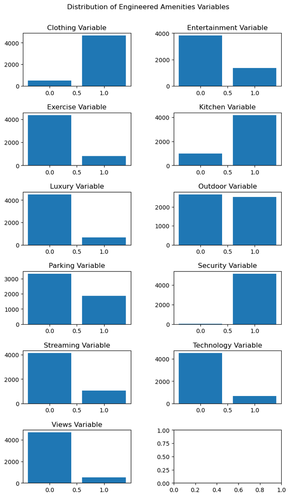

```python
##### Generate Plots to Show Distribution of Amenities Variables #####

fig, axes = plt.subplots(6, 2, figsize=(8,14))
fig.suptitle('Distribution of Engineered Amenities Variables', y=0.93)

plt.subplots_adjust(hspace=0.5, wspace=0.4)

axes[0,0].bar(df.groupby(by='Clothing', as_index=False)['price'].count()['Clothing'], df.groupby(by='Clothing', as_index=False)['price'].count()['price'])
axes[0,0].set_title('Clothing Variable')

axes[0,1].bar(df.groupby(by='Entertainment', as_index=False)['price'].count()['Entertainment'], df.groupby(by='Entertainment', as_index=False)['price'].count()['price'])
axes[0,1].set_title('Entertainment Variable')

axes[1,0].bar(df.groupby(by='Exercise', as_index=False)['price'].count()['Exercise'], df.groupby(by='Exercise', as_index=False)['price'].count()['price'])
axes[1,0].set_title('Exercise Variable')

axes[1,1].bar(df.groupby(by='Kitchen', as_index=False)['price'].count()['Kitchen'], df.groupby(by='Kitchen', as_index=False)['price'].count()['price'])
axes[1,1].set_title('Kitchen Variable')

axes[2,0].bar(df.groupby(by='Luxury', as_index=False)['price'].count()['Luxury'], df.groupby(by='Luxury', as_index=False)['price'].count()['price'])
axes[2,0].set_title('Luxury Variable')

axes[2,1].bar(df.groupby(by='Outdoor', as_index=False)['price'].count()['Outdoor'], df.groupby(by='Outdoor', as_index=False)['price'].count()['price'])
axes[2,1].set_title('Outdoor Variable')

axes[3,0].bar(df.groupby(by='Parking', as_index=False)['price'].count()['Parking'], df.groupby(by='Parking', as_index=False)['price'].count()['price'])
axes[3,0].set_title('Parking Variable')

axes[3,1].bar(df.groupby(by='Security', as_index=False)['price'].count()['Security'], df.groupby(by='Security', as_index=False)['price'].count()['price'])
axes[3,1].set_title('Security Variable')

axes[4,0].bar(df.groupby(by='Streaming', as_index=False)['price'].count()['Streaming'], df.groupby(by='Streaming', as_index=False)['price'].count()['price'])
axes[4,0].set_title('Streaming Variable')

axes[4,1].bar(df.groupby(by='Technology', as_index=False)['price'].count()['Technology'], df.groupby(by='Technology', as_index=False)['price'].count()['price'])
axes[4,1].set_title('Technology Variable')

axes[5,0].bar(df.groupby(by='Views', as_index=False)['price'].count()['Views'], df.groupby(by='Views', as_index=False)['price'].count()['price'])
axes[5,0].set_title('Views Variable')
```

### Transformation of the Neighborhood Cleansed Variable

Similar to the Amenities variable, each cell in the Neighbourhood column contained a list of neighbourhoods that a listing belonged to. There were over 120 unique neighbourhoods listed in the file. Instead of adding 120 new variables to the dataframe, each listing of the dataframe was sorted into one of DC's eight wards.

```python
##### Part 1: Feature Engineering for Neighbourhood Variable #####
# First we will create a list of all neighbourhoods and get the number of unique neighbourhoods

all_neighborhoods = []

for idx in df.index:
    neighborhood_list = [x.strip() for x in df['neighbourhood_cleansed'][idx].split(',')]
    for item in neighborhood_list:
        if item not in all_neighborhoods:
            all_neighborhoods.append(item)

all_neighborhoods_arr = np.array(all_neighborhoods)
print(f'There are {len(np.unique(all_neighborhoods_arr))} unique neighborhoods listed.')
```

```
There are 126 unique neighborhoods listed.
```

```python
##### Part 2: Feature Engineering for Neighbourhood Variable #####
# Next we will generate neighborhood groups given there are over 120 neighborhoods
# Reference: https://publicsafety.fandom.com/wiki/List_of_neighborhoods_of_the_District_of_Columbia_by_ward#Ward_7

all_neighborhoods = [x.lower() for x in all_neighborhoods]

ward1 = ['adams morgan', 'columbia heights', 'howard university', 'le droit park', 'lanier heights', 'mt. pleasant', 'park view', 'pleasant plains', 'shaw']

ward2 = ['burleith/hillandale', 'chinatown', 'downtown', 'dupont circle', 'foggy bottom', 'georgetown', 'gwu','georgetown reservoir', 'kalorama heights', 'logan circle', 'mount vernon square', 'penn quarters', 'southwest employment area', 'west end']

ward3 = ['american university park', 'cathedral heights', 'chevy chase', 'cleveland park', 'colonial village', 'forest hills', 'foxhall crescent', 'foxhall village', 'friendship heights', 'glover park', 'massachusetts avenue heights', 'mclean gardens', 'north cleveland park', 'palisades', 'spring valley', 'tenleytown', 'wesley heights', 'woodland-normanstone terrace', 'woodland/fort stanton','woodley park']

ward4 = ['barnaby woods', 'brightwood','brightwood park','colonial village', 'crestwood', 'fort totten', 'hawthorne', 'manor park', 'petworth', 'lamont riggs', 'shepherd park', 'takoma']

ward5 = ['arboretum', 'bloomingdale', 'brentwood', 'brookland', 'carver langston', 'eckington', 'edgewood', 'fort lincoln', 'fort totten', 'gateway', 'ivy city', 'langdon', 'michigan park', 'north michigan park', 'pleasant hill', 'queens chapel', 'trinidad', 'truxton circle', 'woodridge']

ward6 = ['capitol hill', 'lincoln park', 'kingman park', 'southwest/waterfront']

ward7 = ['benning', 'benning heights', 'burrville', 'capitol view', 'deanwood', 'dupont park', 'eastland gardens', 'fairfax village', 'fort davis park', 'fort dupont', 'greenway', 'hillbrook', 'hillcrest', 'kenilworth', 'lincoln heights', 'marshall heights', 'mayfair', 'naylor gardens', 'penn branch', 'randle highlands', 'river terrace', 'twining']

ward8 = ['barry farm', 'bellevue', 'buena vista', 'congress heights', 'douglas', 'fairlawn', 'garfield heights', 'knox hill', 'navy yard', 'shipley terrace', 'washington highlands']

all_wards = ward1 + ward2 + ward3 + ward4 + ward5 + ward6 + ward7 + ward8

# Get neighborhoods not currently assigned to any ward
list(set(all_neighborhoods) - set(all_wards))

ward1.append('cardozo/shaw')
ward2 = ward2 + ['connecticut avenue/k street', 'sheridan']
ward3.append('van ness')
ward4.append('north portal estates')
ward5 = ward5 + ['university heights', 'north capitol street']
ward6 = ward6 + ['union station', 'stanton park', 'buzzard point', 'fort mcnair']
ward7 = ward7 + ['mahaning heights', 'summit park', 'grant park', 'fairmount heights']
ward8 = ward8 + ['near southeast', 'historic anacostia', 'fort stanton']
```

```python
##### Part 3: Feature Engineering for Neighbourhood Variable #####
# Finally we will create the variable for wards and add them to the dataframe

ward = []

for idx in df.index:
    neighborhood_list = [x.strip() for x in df['neighbourhood_cleansed'][idx].split(',')]

    if len(neighborhood_list) > 1:
        if any(x.lower() in ward1 for x in neighborhood_list):
            ward.append(1)
        elif any(x.lower() in ward2 for x in neighborhood_list):
            ward.append(2)
        elif any(x.lower() in ward3 for x in neighborhood_list):
            ward.append(3)
        elif any(x.lower() in ward4 for x in neighborhood_list):
            ward.append(4)
        elif any(x.lower() in ward5 for x in neighborhood_list):
            ward.append(5)
        elif any(x.lower() in ward6 for x in neighborhood_list):
            ward.append(6)
        elif any(x.lower() in ward7 for x in neighborhood_list):
            ward.append(7)
        elif any(x.lower() in ward8 for x in neighborhood_list):
            ward.append(8)
    elif len(neighborhood_list) < 2:

        holder = ''
        neighborhood_list = holder.join(neighborhood_list).lower()
        if neighborhood_list in ward1:
            ward.append(1)
        elif neighborhood_list in ward2:
            ward.append(2)
        elif neighborhood_list in ward3:
            ward.append(3)
        elif neighborhood_list in ward4:
            ward.append(4)
        elif neighborhood_list in ward5:
            ward.append(5)
        elif neighborhood_list in ward6:
            ward.append(6)
        elif neighborhood_list in ward7:
            ward.append(7)
        elif neighborhood_list in ward8:
            ward.append(8)

df['Ward'] = ward
```

## Final DataFrame

Additional data processing included converting the Room Type variable to an ordinal numeric variable, converting Instant Bookable to a boolean integer, and converting price to a float. The final dataframe contained a total of 5,180 rows.

```python
##### Convert Room Type to Ordinal Variable #####

df['Privacy'] = df['room_type'].replace({'Entire home/apt':1, 'Private room':2, 'Shared room': 3, 'Hotel room':4})

##### Convert Instant Bookable to Boolean Integer #####
df['instant_bookable'] = df['instant_bookable'].replace({'t':1, 'f':0})
```

```python
##### Convert Price to Float #####

prices = []
for price in df['price']:
    if "," in price:
        prices.append(float(''.join(price[1:].split(','))))
    else:
        prices.append(float(price[1:]))

df['price'] = prices
```

```python
##### Finalizing DataFrames #####


listings = df[['host_response_time', 'host_response_rate',
       'host_acceptance_rate', 'host_is_superhost', 'accommodates', 'bedrooms', 'beds', 'instant_bookable', 'price', 'Clothing', 'Entertainment', 'Exercise',
       'Kitchen', 'Luxury', 'Outdoor', 'Parking', 'Security', 'Streaming',
       'Technology', 'Views', 'Ward', 'Privacy', 'review_scores_rating']]

review_mean = listings['review_scores_rating'].mean()
target = []

for rating in listings['review_scores_rating']:
    if rating >= review_mean:
        target.append(1)
    else:
        target.append(0)

listings['Target'] = target
```

# 3. Exploratory Data Analysis

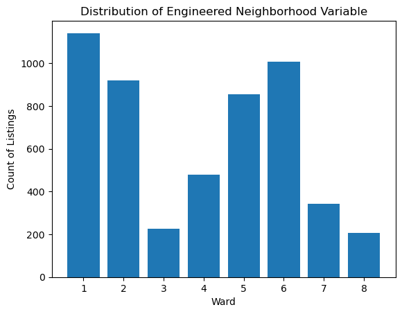

```python
##### Generate Plot to Show Distribution of Neighborhoods Variables #####
plt.bar(df.groupby(by='Ward', as_index=False)['price'].count()['Ward'],df.groupby(by='Ward', as_index=False)['price'].count()['price'])
plt.title('Distribution of Engineered Neighborhood Variable')
plt.xlabel('Ward')
plt.ylabel('Count of Listings')
```

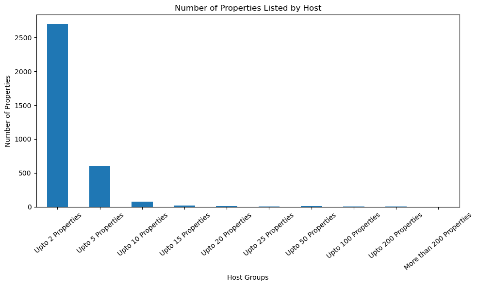

```python
#barplot for hosts with more than 1 property

host_property_count = data['host_id'].value_counts()
host_property_count_df = pd.DataFrame({'host_id': host_property_count.index, 'property_count': host_property_count.values})
host_property_count_df = host_property_count_df.sort_values(by='property_count', ascending=False)

#range and range labels
ranges = [1,2,5,10,15,20,25,50,100,200,float('inf')]
range_labels = [' Upto 2 Properties',' Upto 5 Properties',' Upto 10 Properties',' Upto 15 Properties', 'Upto 20 Properties', 'Upto 25 Properties','Upto 50 Properties', 'Upto 100 Properties', 'Upto 200 Properties', 'More than 200 Properties']
host_property_count_df['property_count_range'] = pd.cut(host_property_count_df['property_count'], bins=ranges, labels=range_labels, right=False)

# Group the data by property count range and count the number of hosts in each range
grouped_counts = host_property_count_df.groupby('property_count_range')['host_id'].count()


plt.figure(figsize=(10, 6))
grouped_counts.plot(kind='bar')
plt.xlabel('Host Groups')
plt.ylabel('Number of Properties')
plt.title('Number of Properties Listed by Host')
plt.xticks(rotation=40)  # To avoid overlap of host IDs on x-axis
plt.tight_layout()
#plt.ylim(top = 100)
plt.show()
```

There are times when customers want to book an Airbnb but it is not favorable to them due to a singular unfavorable factor in the long list of factors. The reason they decide to choose that airbnb that they could not book at the last minute was most likely because of its certain features that instantly got their attention, fit their price bracket and needs. One thing that can be done in this case as a product developer is to know how many bunch of properties exists that all come under a single host. it will allow us to take that information and utilize it to find and design recommendation system to recommend other airbnb that might suite the customer if they were unable to finalize on an airbnb before.

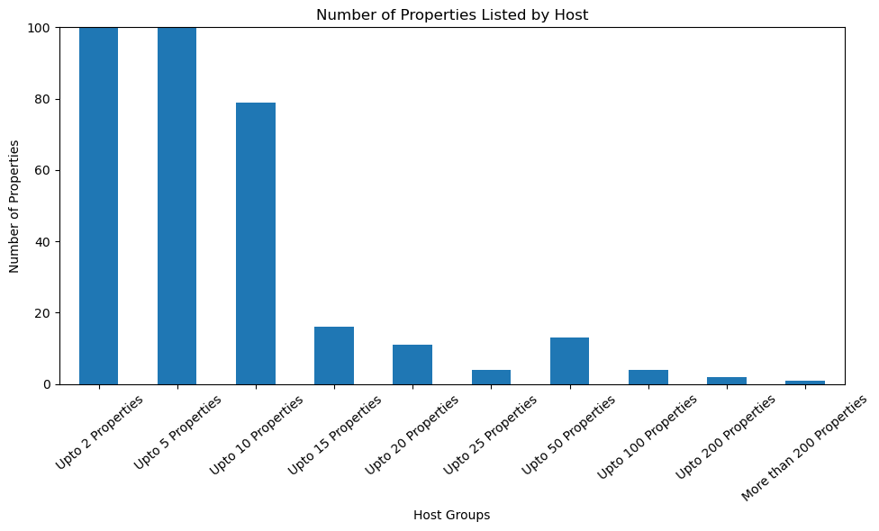

```python
plt.figure(figsize=(10, 6))
grouped_counts.plot(kind='bar')
plt.xlabel('Host Groups')
plt.ylabel('Number of Properties')
plt.title('Number of Properties Listed by Host')
plt.xticks(rotation=40)  # To avoid overlap of host IDs on x-axis
plt.tight_layout()
plt.ylim(top = 100)
plt.show()
```

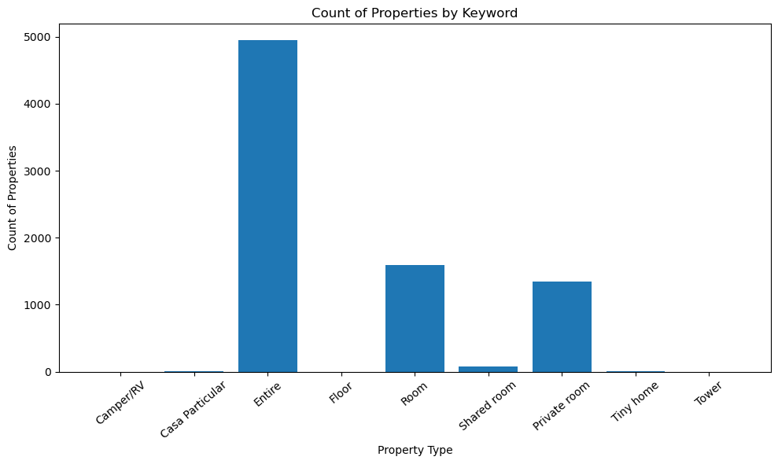

```python
base_keywords=['Camper/RV','Casa Particular', 'Entire','Floor','Room','Shared room','Private room','Tiny home','Tower']

keyword_counts = {keyword: 0 for keyword in base_keywords}

for keyword in base_keywords:
    propcount = data[data['property_type'].str.contains(keyword,case=False,na=False)].shape[0]
    keyword_counts[keyword] = propcount

plt.figure(figsize=(10, 6))
plt.bar(keyword_counts.keys(),keyword_counts.values())
plt.xlabel('Property Type')
plt.ylabel('Count of Properties')
plt.title('Count of Properties by Keyword')
plt.xticks(rotation=40)  # To avoid overlap of host IDs on x-axis
plt.tight_layout()
plt.show()
```

Then we tried to group keywords from the property type variable to see how many properties belong to a certain type as it will help us visualize the most commonly available listings in the airbnbs of washington dc.

We applied string operations to find counts of properties with such keywords and plotted a bar graph for the same which revealed us the information that most the airbnb's are listed on an **ENTIRE** basis and quite significantly so. It was immediately followed by count of rooms and private rooms listed in a otherwise owned and in-use living space for the prior/existing owner/rentee. All the other types of properties were very less in number. The x-axis contains all the types of property while the y-axis contains the number of properties that particular property type. This plots shows us the inclination of people to stay in these three property type which is being taken into account by the hosts.

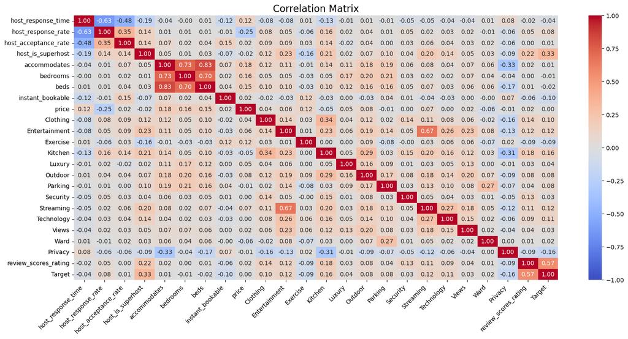

```python
plt.figure(figsize=(16,8))
ax= plt.axes()
correlation_mat = listings.corr()
sns.heatmap(correlation_mat,annot=True,cmap='coolwarm',ax=ax, fmt = '0.2f', annot_kws = {'size' : 10},vmin=-1,center=0,vmax=1)
plt.title('Correlation Matrix', fontsize = 16)
ax.set_xticklabels(ax.get_xticklabels(), rotation = 45, horizontalalignment = 'right')
cbar = ax.collections[0].colorbar
# cbar.set_ticks([-1, -0.5, 0, 0.5, 1])
# cbar.set_ticklabels(['-1', '-0.5', '0', '0.5', '1'])
plt.tight_layout()
plt.show()
```

The Correlation plot essentially allows us to visualize 2 things - First, correlation of feature set variables with the target variable and Second, correlation amongst the features. It is important to know this information priorhand as it sets the foundation for solving the problem at hand. On both the x and y axis we have the features and their correlation values in the intersecting blocks of lines forming the squares. The values of the correlation varies from -1 to 1. 1 represents strong positive and -1 represents strong negative correlation. values closer to zero represent weaker to no correlation. Looking at correlation matrix/plot is part of the standard procedure to have a first look at the problems that may or may not arise with the large dimensional data like this Airbnb data. One of the very important thing that we need to worry about is the problem of multi-collinearity. Multicollinearity occurs when we have variables that are showing correlation amongsts themselves in the feature set. While it may be bothersome in first glance but it should not be a basis for a conclusive decision that our data now has multicollinearity.

On visual inspection there is correlation present between feature set variables but we can conclude that it is in fact true based on variance inflation factor. Later on in the modelling phase, we will take a look at Variance Inflation factor(V.I.F.) to further determine if the feature space needs some reduction for the baseline modelling itself by cutting down on features that are showing high correlation with each other. The concept is simple, for the multicollinearity to be proven, the metric VIF number should be 5 and above in terms of its scaler value. In this project, we will analyze the VIF number when we are making models to see if we have to reduce our feature space and tune the models to remove multicollinearity and progress towards more accurate results.

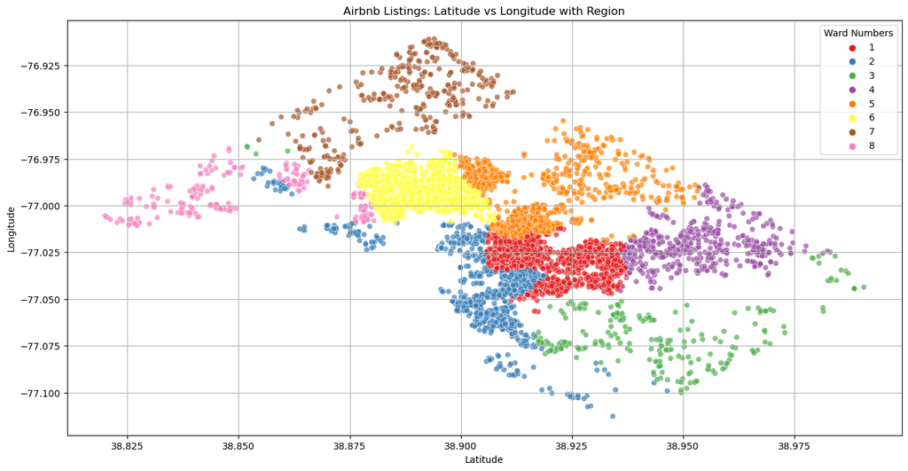

```python
plt.figure(figsize=(16, 8))
sns.scatterplot(x='latitude', y='longitude', hue='Ward', data=df, palette='Set1', alpha=0.7)
plt.title('Airbnb Listings: Latitude vs Longitude with Region')
plt.xlabel('Latitude')
plt.ylabel('Longitude')
plt.legend(title='Ward Numbers')
plt.grid(True)
plt.show()
```

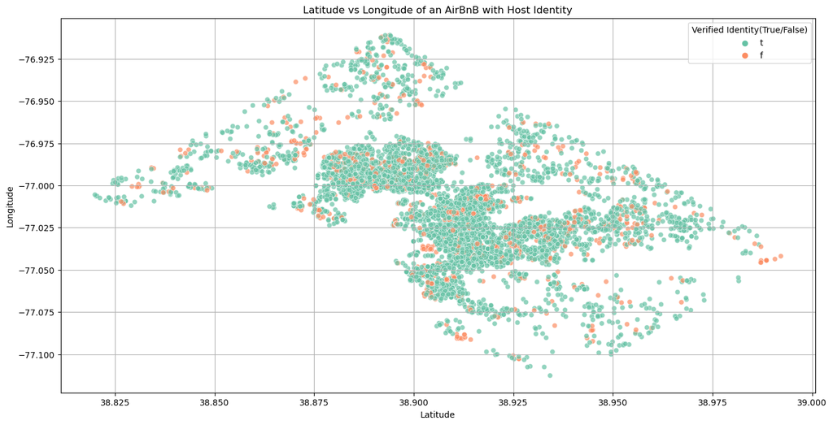

```python
plt.figure(figsize=(16, 8))
sns.scatterplot(x='latitude', y='longitude', hue='host_identity_verified', data=data, palette='Set2', alpha=0.7)
plt.title('Latitude vs Longitude of an AirBnB with Host Identity')
plt.xlabel('Latitude')
plt.ylabel('Longitude')
plt.legend(title='Verified Identity(True/False)')
plt.grid(True)
plt.show()
```

To build up on the previous scatterplot and to answer a question of security that is usually the first concern for someone trying to book an Airbnb, we went ahead and plotted another scatter plot that represented the pseudo map of the DC area. only this time, we had the security concern that needed to be answered at the top of our priority order. There are times when we see a listing with all the underwhelming and pixelated photos of the property which gives us the scary feeling that the listing might be fake It is not favorable for us as a customer to put money and trust in a listing that may very well not even exist at all and might just be fake at best.

That is where this scatter plot helps us visualize that data. Here we plot the same latitude and longitude but with a different hue and that being of whether the owner is verified airbnb host or not a verified host. This shows us and help us assure the user to steer them towards the verified hosts listing real properties to ensure the customer satisfaction at its best. We find that most of the hosts on Airbnb are real and verified in this data from 2013 to the present.

```
[Text(0, 0, '1518'), Text(0, 0, '3662')]
```

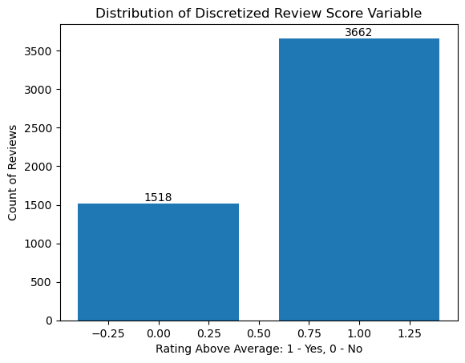

```python
##### Plot the New Discretized Review Scores Variable #####
fig, ax = plt.subplots()
bars = ax.bar(listings.groupby(by=['Target'], as_index=False)['review_scores_rating'].count()['Target'], listings.groupby(by=['Target'], as_index=False)['review_scores_rating'].count()['review_scores_rating'])

plt.title('Distribution of Discretized Review Score Variable')
plt.xlabel('Rating Above Average: 1 - Yes, 0 - No')
plt.ylabel('Count of Reviews')

ax.bar_label(bars)
```